2022-07-14

# Overview

Investigating bootstrapped curves from observed dataset. Two groups, `"CI"` and `"NH"` specified by `protocol`, with 28 and 26 subjects in each group, respectively

For part one of this, we are going to look at observed data, fit it, and compare the distribution of fitted curves to the bootstrapped output. It’ll look super wonky, so to try and control for variability, we will try it again by using only about 10% of the subjects

Part two of this will involve a simulation to see if our results are as nonsensical as they seem

Part 3 repeated with more discrete points

Part 4 examines using quantiles instead of sd

# Part 1

## Original Fit

First, the fitting step is done, with all fits having zero fit code. Coefficients were extracted from each group and used to construct subject level curves within each group

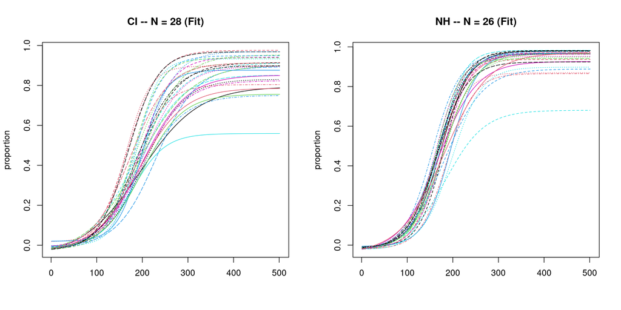

Following this, we go to the bootstrap. This first plot returned is from the plotting method for the boot object

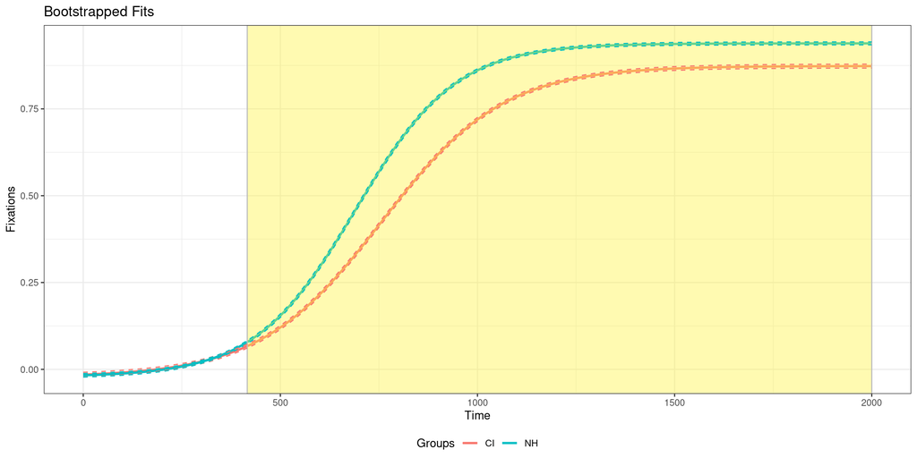

But we can also extact the individual curves from each of the 1000 simulations. Though that is what is shown here, it looks nearly identical with 100 instead. Recall how this works is that each subject draws $N$ sets of parameters from the distribution returned by `gnls`, creating the $N\times p$ matrix $M_i$. We get the group level matrix $M_{\theta} = \frac1n \sum M_i$, also $N \times p$, with the group mean and sd derived from the rows.

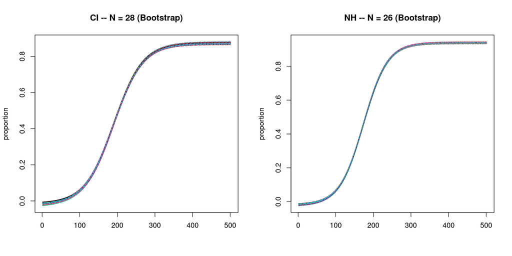

## Subset of original

As there seems to be pretty minimal variability between the rows of $M_{\theta}$, I figured it might be a consequence of the number of subjects in each group. To add additional variability, I subset the first four subjects from each group, and then repeated the construction of the curves above

Starting with the four chosen from the fit object (these haven’t been refit, so they are four of the original 28/26 in the plot above)

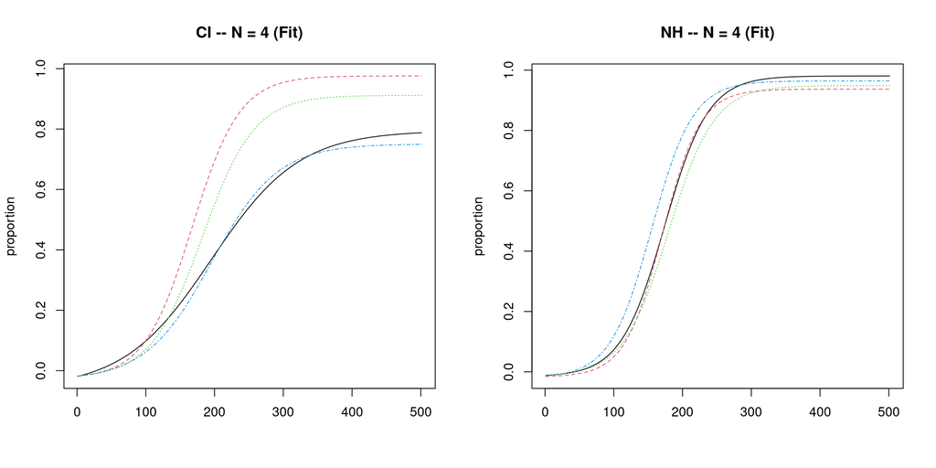

And again bootstrapping these, plotting with both the CI and the full collection of curves

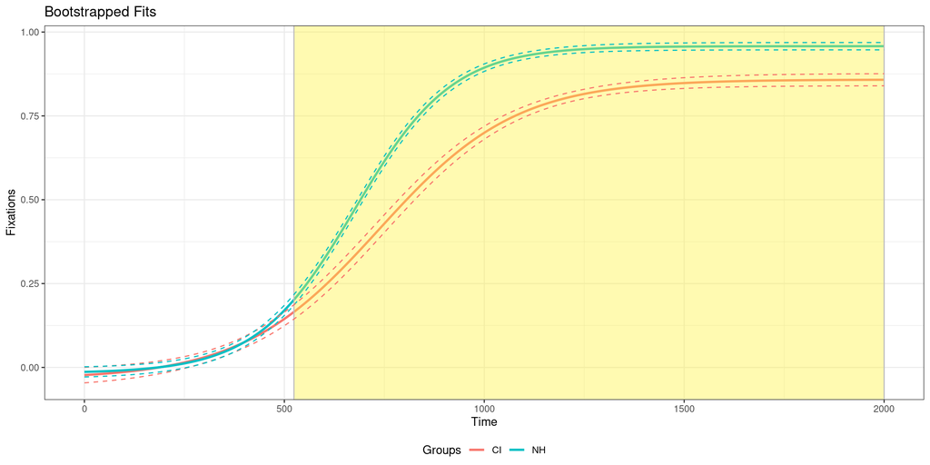

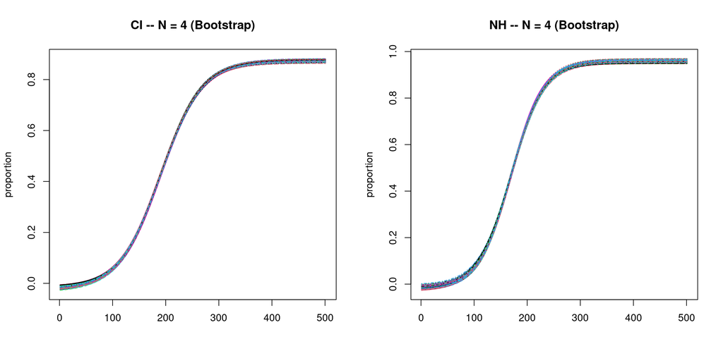

# Part 2

In considering our simulation, here’s what we do: I’m going to select one subject from each of the groups, get the parameter estimates and covariance matrix from `gnls`, multiply that matrix by 15, and then use the resulting distribution to draw 20 subjects from each group. We will then repeat what we did above.

Note: I went ahead and added a part 3 which is identical to part 2 (including a seed), but with time at 2ms intervals rather than 4, in case that was adding any discrepancy (can’t do more than 1000 observed points thanks to mvtnorm)

I’ll skip showing the “observed” curves, as they’re recovered pretty well by the fitting function (as to be expected). Superimposed on each plot is a thick black line indicating the mean of the generating distribution for parameters

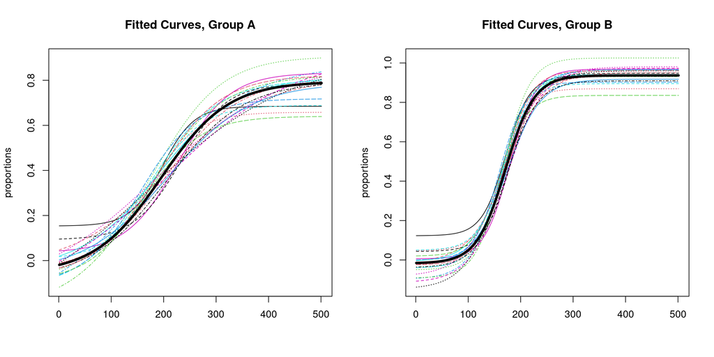

Unsurprisingly, the confidence intervals for this curve are virtually nonexistent.

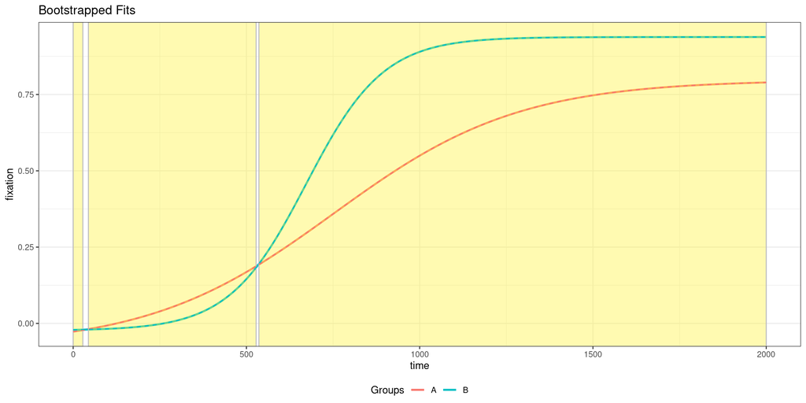

Plotting just the bootstrapped curves, along with, again, a thick black line indicating the generating parameters, we do see that it’s suprisingly close

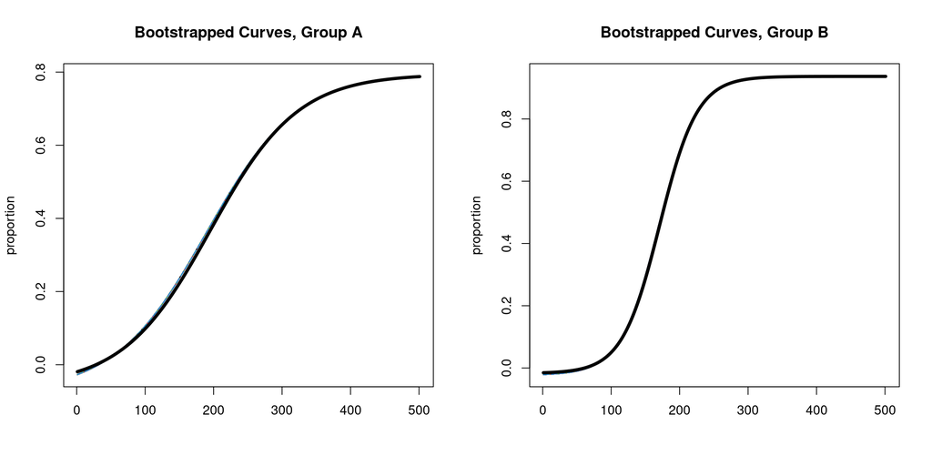

But they’re not exact exact. We can see that by zooming in on one of the groups

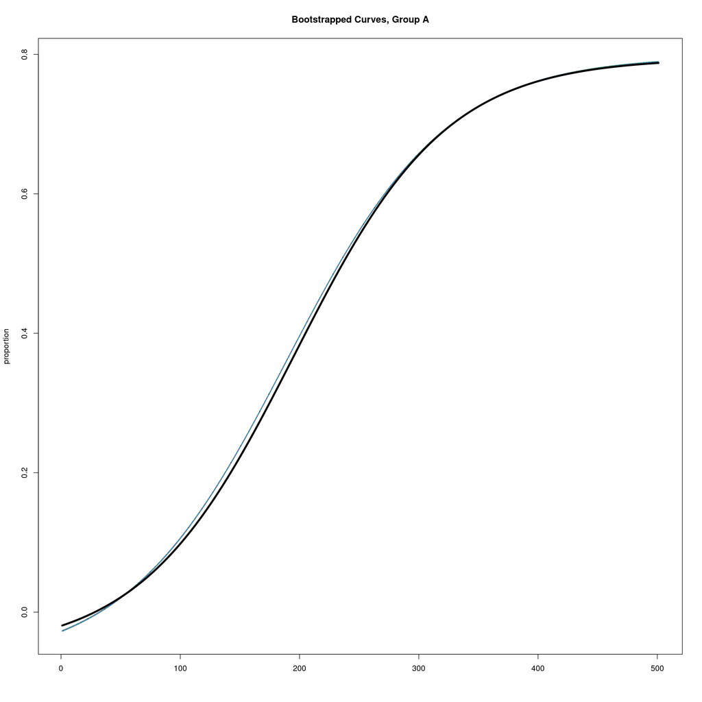

### Parameters

Note that the original parameters used

Group A

|  | mini | peak | slope | cross |
| --- | --- | --- | --- | --- |
| Starting coefficient | -0.05762 | 0.79477 | 0.00084 | 778.23 |
| Mean bootstrapped value | -0.07644 | 0.79759 | 0.00082 | 752.32 |

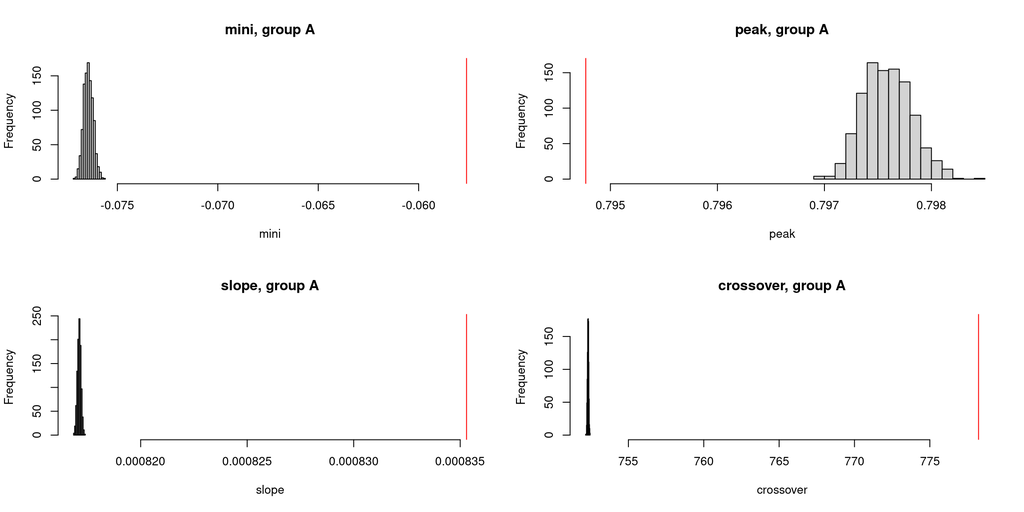

Group B

|  | mini | peak | slope | cross |
| --- | --- | --- | --- | --- |
| Starting coefficient | -0.01720 | 0.93682 | 0.00217 | 679.87 |
| Mean bootstrapped value | -0.02337 | 0.93831 | 0.00216 | 672.54 |

[figure not shown]

### Observed vs Bootstrapped

To come back to the comparison between the distribution of fitted curves and the bootstrapped curves, maybe it doesn’t do as terrible of a job capturing the group mean as I would have imagined, though certainly not at the rate advertised

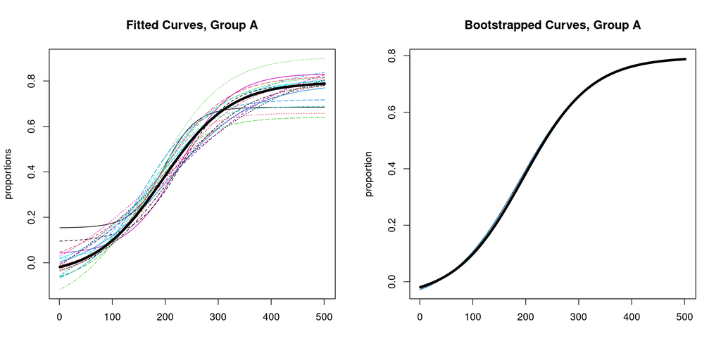

# Part 3

I’ll skip everything and just move down to the plots at the end. The difference here is sampling is at 2ms rather than 4

Really, it doesn’t seem like we did all that much better. I could try again with higher density points over smaller time window, I guess

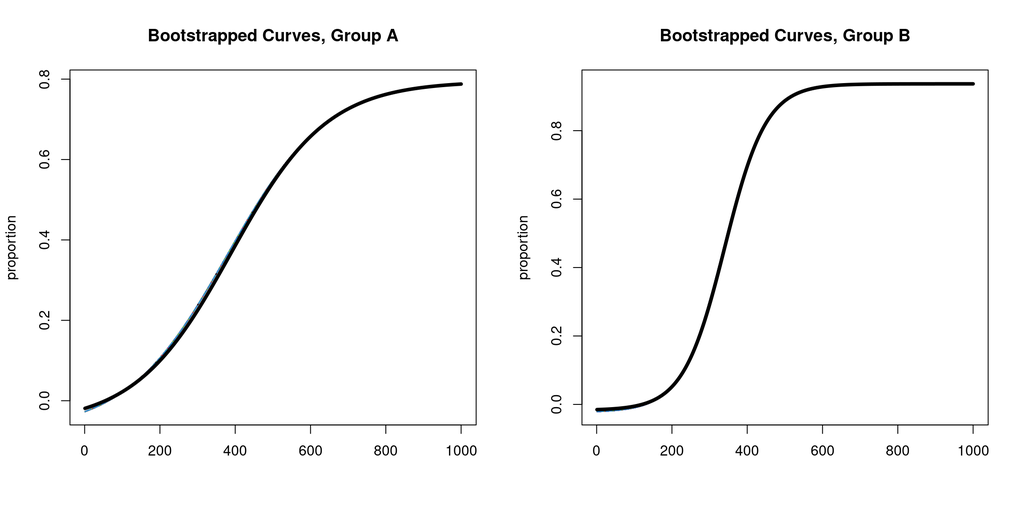

Zoomed in

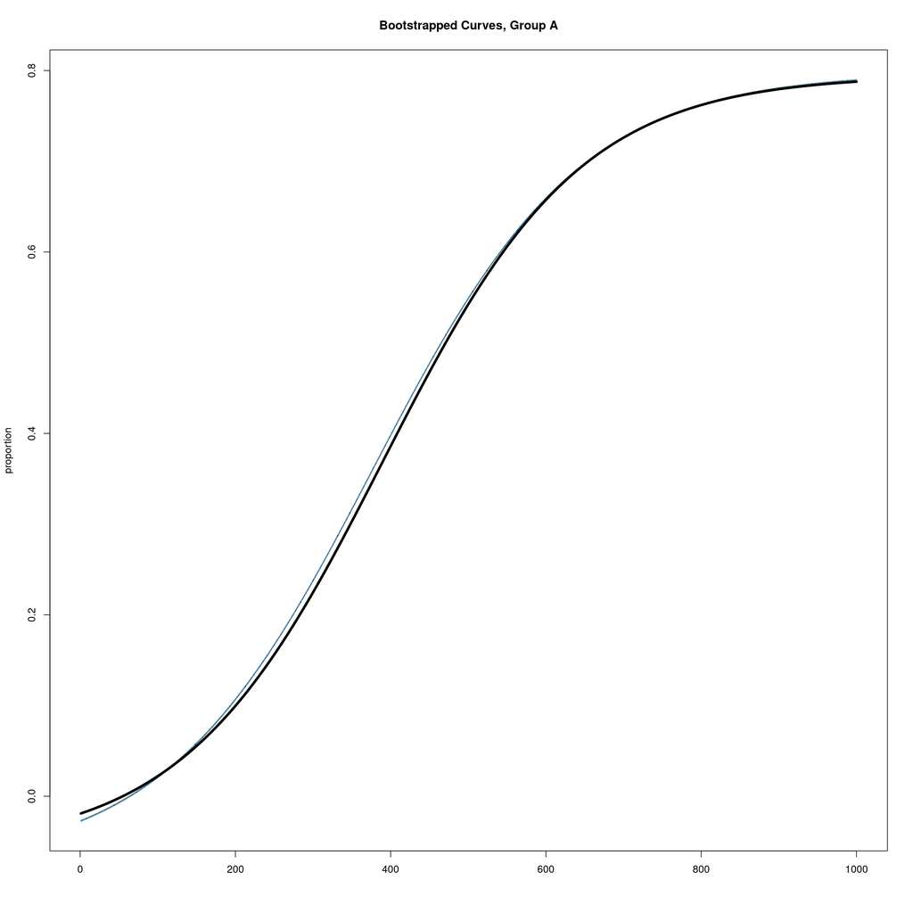

# Part 4 (quantiles)

Here, we are considering the CI group, looking at plot generated with critical value and SD, the other considering quantiles

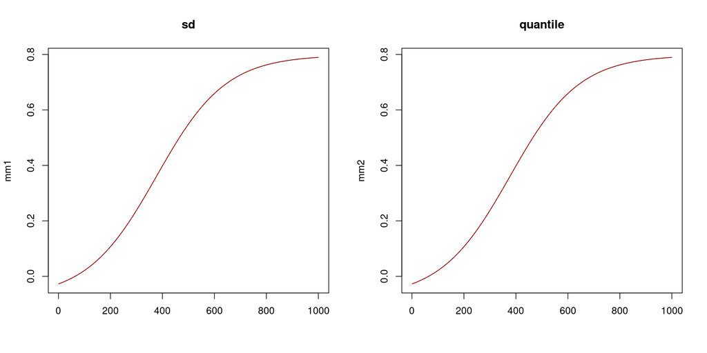

We can also consider the difference and ratio between the two (sd - quantile, sd / quantile)

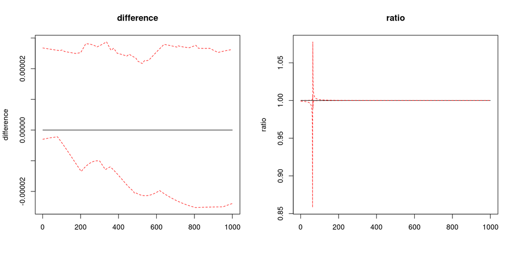

# Part 5 (Iterations)

Does the number of iterations matter? Here we run bootstrap with $N = 10, 1000$ iterations and look again at difference and ratio of standard deviations

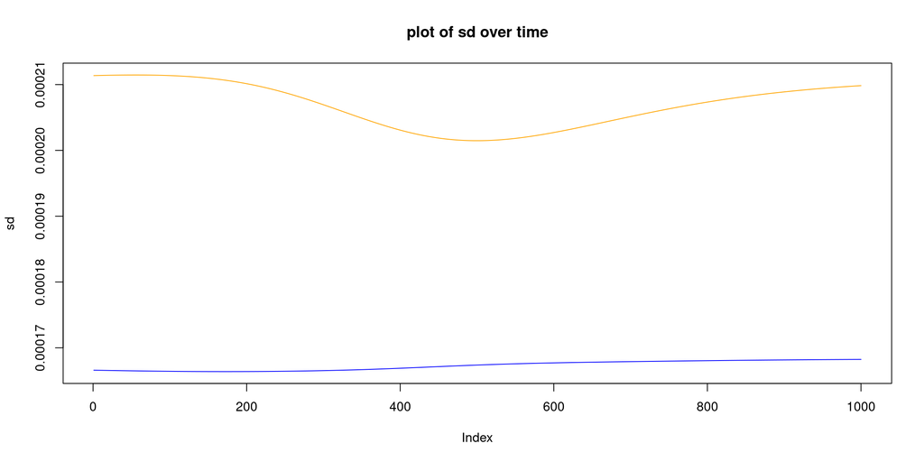

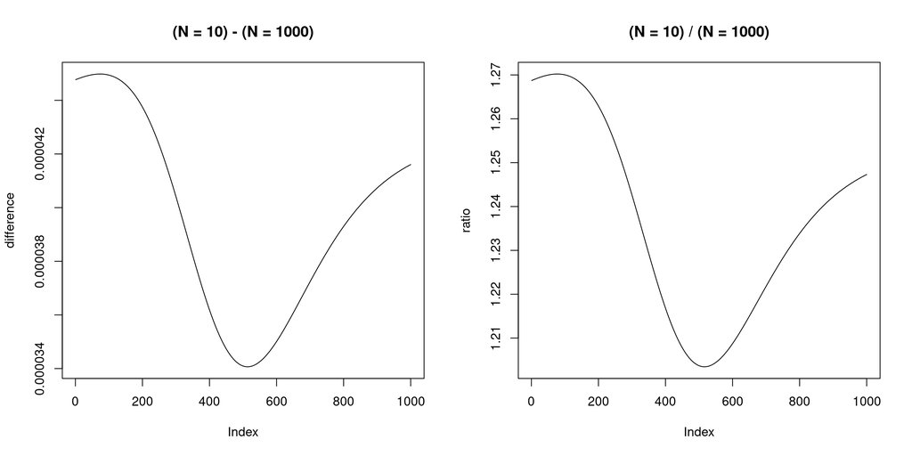